# Lab assignment 2 - Helen Hsu

In class and during the lab, we investigated the birthday problem: What is the probability that among a relatively *large* number of people, *two people* are born on the same day. A little more abstractly, we wondered about the probability that choosing from a large number of options (the 365 days) sufficiently many times (say 23 or 39 times, the number of people you’re interested in) results in the same option being selected twice.

In this assignment we ask a similar but somewhat opposite question: What is the probability that among a relatively *small* number of people, *all people* are born in the same season. A little more abstractly again, we will wonder about the probability that choosing from a small number of options (the 4 seasons) even a small number of times (small groups of 2 to 10), all the options end up being the same.

## 0. Set seed

```r
set.seed(1234)
```

## 1. Analytical solution

**[1 points]** Compute analytically (i.e., using the correct *exact* math formula) the probability that a group of `n` friends are all born in the same season (there are 4 seasons and you should assume all seasons are equally likely and independent across friends). Store the probabilities for all `n` between 2 and 10 into a vector called `math` and display the values in that vector.

The result should look as follows:

```r
library(gtools)
n <- c(2:10)
math <- choose(4, 1)/(4^n)
math
```

```
## [1] 2.500000e-01 6.250000e-02 1.562500e-02 3.906250e-03 9.765625e-04
## [6] 2.441406e-04 6.103516e-05 1.525879e-05 3.814697e-06
```

## 2. Simulation

### a) First steps: two friends

**[1 points]** Draw two numbers with equal probability from 1,2,3,4 (representing the four seasons), with replacement. Store the two numbers in a vector called `seas` and display the value of the vector.

Given how you set the random seed and assuming you sample the two numbers in the “standard” way we learned during the lab, the result should look as follows.

```r
set.seed(1234)
seas <- sample(1:4, 2, replace = T)
seas
```

```
## [1] 1 3
```

**[1 points]** Check whether all the numbers in your `seas` vector are the same and display the result.

```r
any(duplicated(seas))
```

```
## [1] FALSE
```

**[2 points]** Let’s now simulate the above process for 1000 times. Draw 1000 vectors of two numbers with equal probability from 1,2,3,4 with replacement. For each vector check wether all the numbers are the same, and record the number of vectors for which this is the case. Finally, report the proportion of the 1000 vectors for which all the numbers are the same

```r
set.seed(1234)
N <- 1000
n.matches <- 0
for (i in 1:N) {
  seas <- sample(1:4, 2, replace = T)
  if (length(unique(seas)) == 1) {
    n.matches <- n.matches + 1
  }
}
n.matches/N
```

```
## [1] 0.249
```

### b) Generalize to `n` friends for `n` between 2 and 10

**[4 points]** Repeat the last step for every vector length (i.e., every number of friends) between 2 and 10. For each vector length, record the proportion of the 1000 vectors for which all the numbers are the same into a vector called `rec`. Finally, display vector `rec`.

```r
set.seed(1234)
N <- 1000
n <- c(2:10)
length(n)
```

```
## [1] 9
```

```r
rec <- rep(0,9)
for (j in 1:9) {
  n.matches <- 0
  for (i in 1:N) {
    seas <- sample(1:4, size = n[j], replace = T)
    if (length(unique(seas)) == 1) {
      n.matches <- n.matches + 1
      rec[j] <- n.matches/N
    }
  }
}
rec
```

```
## [1] 0.249 0.052 0.016 0.003 0.000 0.000 0.000 0.000 0.000
```

## 3. Compare simulation and analytical results

**[1 points]** Plot the results of your simulation (vector `rec`) in red and the analytical result (vector `math`) in green on the same graph.

You can overlay two vectors `x` and `y` on the same graph using the following code:

`plot(x,type="b",col="red")`

`lines(y,type="b",col="green")`

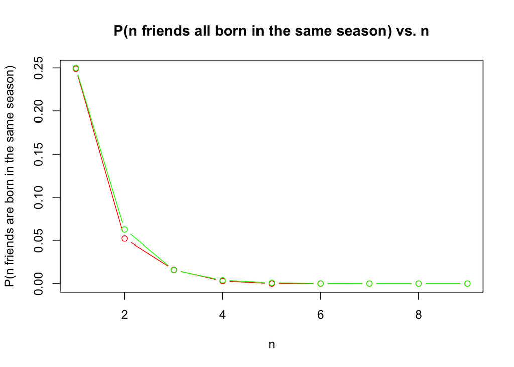

```r
plot(rec,type='b',col='red',
     main = "P(n friends all born in the same season) vs. n",
     xlab = "n", ylab = "P(n friends are born in the same season)",)
lines(math, col = "green", type = "b")
```